# Excess mortality

Final outputs for paper and appendix

# Paper outputs

## Table 1

| Country | Population | Observed | Expected | Excess No. | Excess 95% CrI | % excess % | % excess 95% CrI |
| --- | --- | --- | --- | --- | --- | --- | --- |
| **1890** |  |  |  |  |  |  |  |
| Switzerland | 2960800 | 61805 | 58355 | 3451 | (711, 6123) | 5.9% | (1.2%, 10.5%) |
| Sweden | 4784981 | 81824 | 73042 | 8782 | (4830, 12435) | 12.0% | (6.6%, 17.0%) |
| **1918** |  |  |  |  |  |  |  |
| Switzerland | 3871870 | 75034 | 50256 | 24779 | (21958, 27548) | 49.3% | (43.7%, 54.8%) |
| Sweden | 5813850 | 104591 | 78570 | 26022 | (20898, 30895) | 33.1% | (26.6%, 39.3%) |
| Spain | 21192701 | 695758 | 453698 | 242061 | (216201, 267526) | 53.4% | (47.7%, 59.0%) |
| **1957** |  |  |  |  |  |  |  |
| Switzerland | 5130100 | 51066 | 52027 | -961 | (-3812, 1632) | -1.8% | (-7.3%, 3.1%) |
| Sweden | 7388611 | 73132 | 70356 | 2775 | (179, 5316) | 3.9% | (0.3%, 7.6%) |
| Spain | 29499414 | 293502 | 280210 | 13292 | (-3401, 28970) | 4.7% | (-1.2%, 10.3%) |
| **2020** |  |  |  |  |  |  |  |
| Switzerland | 8636560 | 75570 | 66093 | 9478 | (6380, 12482) | 14.3% | (9.7%, 18.9%) |
| Sweden | 10379295 | 97870 | 90199 | 7671 | (4247, 11013) | 8.5% | (4.7%, 12.2%) |
| Spain | 47353706 | 492930 | 422004 | 70926 | (50451, 90911) | 16.8% | (12.0%, 21.5%) |
| **2021** |  |  |  |  |  |  |  |
| Switzerland | 8636560 | 34454 | 34330 | 125 | (-1850, 2080) | 0.4% | (-5.4%, 6.1%) |
| Spain | 47353706 | 234826 | 221664 | 13163 | (-292, 26482) | 5.9% | (-0.1%, 11.9%) |

## Figure 1

Monthly absolute estimates of excess.

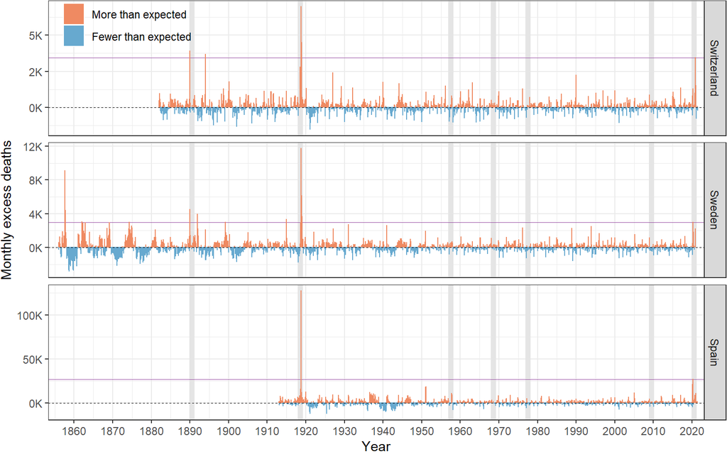

## Figure 2

Zooming to pandemics to explore absolute excess with CrI.

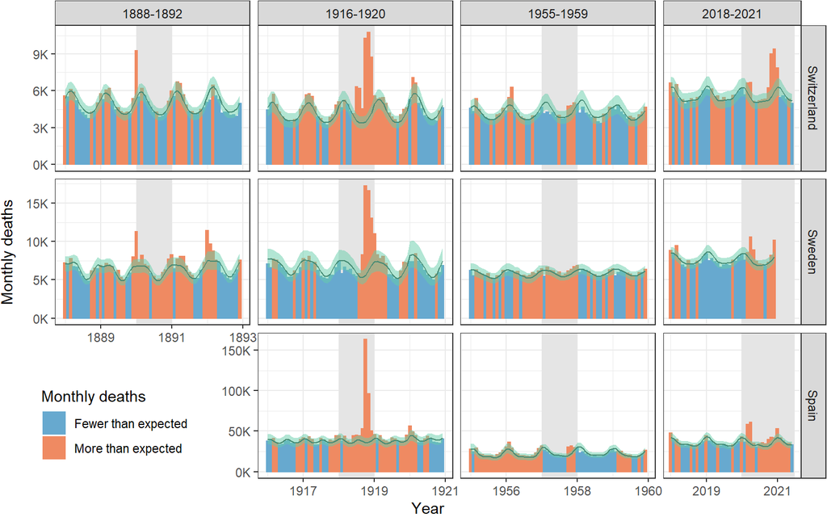

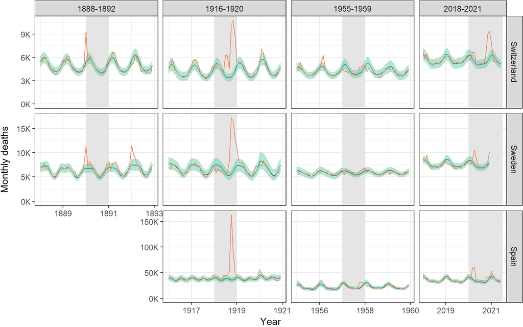

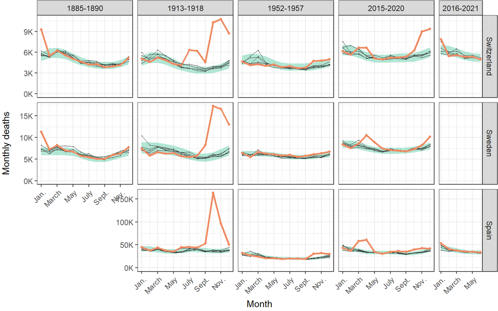

## Figure 3

Age differences across major pandemics

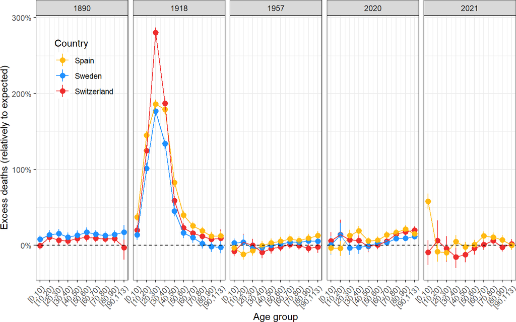

# Appendix

## Table S1

Comparing estimates of excess from different methods

| Year | Poisson Serfling Excess | NB Serfling Excess | NB Serfling 95% CrI | NB serfling (age) Excess | NB serfling (age) 95% CrI |
| --- | --- | --- | --- | --- | --- |
| **Switzerland** |  |  |  |  |  |
| 1889 | 928 | 1148 | (-1667, 3909) | 1345 | (-1548, 4005) |
| 1890 | 3408 | 3356 | (541, 6078) | 3451 | (711, 6123) |
| 1891 | 2024 | 1593 | (-1471, 4492) | 1955 | (-1328, 4976) |
| 1917 | 3621 | 3833 | (1138, 6502) | 3832 | (1212, 6476) |
| 1918 | 24562 | 24692 | (21817, 27411) | 24779 | (21958, 27548) |
| 1919 | 3763 | 3654 | (352, 6730) | 3750 | (437, 6918) |
| 1956 | 1556 | 1470 | (-893, 3756) | 1513 | (-778, 3744) |
| 1957 | -1215 | -1046 | (-3859, 1658) | -961 | (-3812, 1632) |
| 1958 | -3376 | -3234 | (-6396, -148) | -3603 | (-6833, -595) |
| 2019 | 233 | 315 | (-2991, 3505) | 202 | (-2994, 3370) |
| 2020 | 8123 | 7959 | (4808, 11009) | 9478 | (6380, 12482) |
| 2021 | -803 | -668 | (-2696, 1365) | 125 | (-1850, 2080) |
| **Sweden** |  |  |  |  |  |
| 1889 | 2473 | 2208 | (-1577, 5915) | 2448 | (-1396, 5970) |
| 1890 | 8747 | 8514 | (4555, 12370) | 8782 | (4830, 12435) |
| 1891 | 6268 | 5405 | (822, 9767) | 5374 | (976, 9670) |
| 1917 | -3025 | -2935 | (-8320, 2093) | -2695 | (-7899, 2294) |
| 1918 | 25949 | 26037 | (20771, 31224) | 26022 | (20898, 30895) |
| 1919 | 8440 | 7293 | (1320, 13151) | 7296 | (1279, 13184) |
| 1956 | 1574 | 1397 | (-2176, 4740) | 1050 | (-2609, 4433) |
| 1957 | 3069 | 3007 | (299, 5594) | 2775 | (179, 5316) |
| 1958 | 1252 | 783 | (-2333, 3741) | -335 | (-3528, 2714) |
| 2019 | -4114 | -3960 | (-7751, -278) | -4347 | (-8046, -850) |
| 2020 | 8894 | 8814 | (5519, 12130) | 7671 | (4247, 11013) |
| 2021 | 1919 | 1081 | (-1496, 3541) | NA | NA |
| **Spain** |  |  |  |  |  |
| 1917 | 12312 | 11887 | (-12754, 36380) | 11957 | (-13513, 35647) |
| 1918 | 243980 | 244012 | (218658, 267417) | 242061 | (216201, 267526) |
| 1919 | 26502 | 25389 | (-2679, 51965) | 28747 | (1882, 54960) |
| 1956 | 39615 | 33331 | (10713, 54946) | 32416 | (9151, 53990) |
| 1957 | 10613 | 11667 | (-5235, 27206) | 13292 | (-3401, 28970) |
| 1958 | -33028 | -29316 | (-49105, -10269) | -28860 | (-48158, -9413) |
| 2019 | -21233 | -20616 | (-42795, 761) | -13200 | (-33870, 7717) |
| 2020 | 67428 | 66826 | (45817, 87210) | 70926 | (50451, 90911) |
| 2021 | 11317 | 11860 | (-3219, 26026) | 13163 | (-292, 26482) |

## Figure S1

Yearly estimates of excess; **2021 not included since not full year**.

[figure not shown]

## Figure S2

Zooming to pandemics to explore % of excess

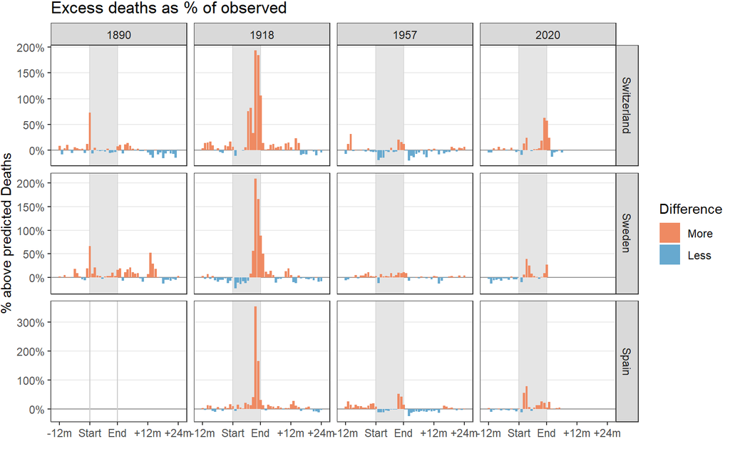

## Figure S3

Impact of extremes: using 1918 pandemic as an example of impact on estimates from 1919 - 1923.  
Estimates with extreme year (blue) and without (red).  
Converge after 5 year smoothing window stops having effect (ie. in 1924).

### Figure 1918

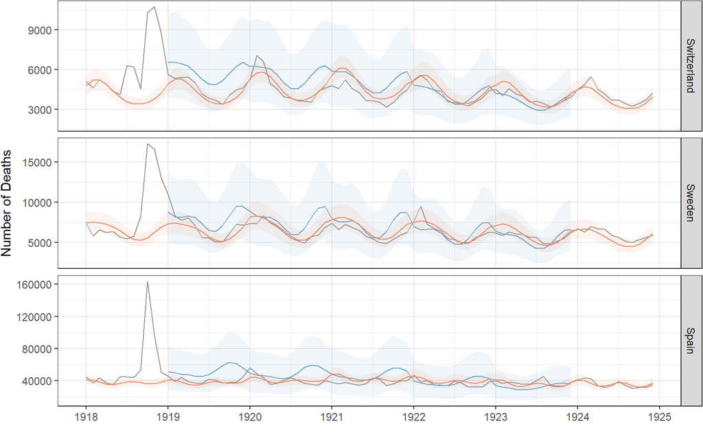

### Table 1918

Using 1918 pandemic as an example of impact on estimates from 1919.

| Country | Month | Observed | Including 1918 Predicted | Including 1918 Difference | Excluding 1918 Predicted (pandemic) | Excluding 1918 Difference |
| --- | --- | --- | --- | --- | --- | --- |
| Switzerland | 1 | 5599 | 4912 | 687 | 6587 | -988 |
| Switzerland | 2 | 5324 | 5284 | 40 | 6543 | -1219 |
| Switzerland | 3 | 5404 | 5294 | 110 | 6453 | -1049 |
| Switzerland | 4 | 5451 | 4960 | 491 | 6258 | -807 |
| Switzerland | 5 | 4976 | 4448 | 528 | 5791 | -815 |
| Switzerland | 6 | 4166 | 3968 | 198 | 5272 | -1106 |
| Switzerland | 7 | 3851 | 3614 | 237 | 4930 | -1079 |
| Switzerland | 8 | 3674 | 3429 | 245 | 4846 | -1172 |
| Switzerland | 9 | 3370 | 3416 | -46 | 5155 | -1785 |
| Switzerland | 10 | 4043 | 3569 | 474 | 5716 | -1673 |
| Switzerland | 11 | 4465 | 3902 | 563 | 6244 | -1779 |
| Switzerland | 12 | 4609 | 4386 | 223 | 6533 | -1924 |
| Sweden | 1 | 10999 | 7333 | 3666 | 8833 | 2166 |
| Sweden | 2 | 8289 | 7432 | 857 | 8218 | 71 |
| Sweden | 3 | 7781 | 7310 | 471 | 8165 | -384 |
| Sweden | 4 | 8076 | 7104 | 972 | 8322 | -246 |
| Sweden | 5 | 7137 | 6828 | 309 | 8115 | -978 |
| Sweden | 6 | 5647 | 6365 | -718 | 7339 | -1692 |
| Sweden | 7 | 5590 | 5767 | -177 | 6549 | -959 |
| Sweden | 8 | 5093 | 5286 | -193 | 6393 | -1300 |
| Sweden | 9 | 5083 | 5145 | -62 | 7103 | -2020 |
| Sweden | 10 | 6120 | 5445 | 675 | 8350 | -2230 |
| Sweden | 11 | 7289 | 6116 | 1173 | 9494 | -2205 |
| Sweden | 12 | 7185 | 6861 | 324 | 9490 | -2305 |
| Spain | 1 | 45826 | 40902 | 4924 | 51788 | -5962 |
| Spain | 2 | 39277 | 41071 | -1794 | 49832 | -10555 |
| Spain | 3 | 44287 | 38697 | 5590 | 48418 | -4131 |
| Spain | 4 | 38960 | 35809 | 3151 | 47637 | -8677 |
| Spain | 5 | 37423 | 34663 | 2760 | 45823 | -8400 |
| Spain | 6 | 36609 | 35746 | 863 | 45424 | -8815 |
| Spain | 7 | 41756 | 37876 | 3880 | 47395 | -5639 |
| Spain | 8 | 40557 | 38974 | 1583 | 52824 | -12267 |
| Spain | 9 | 37199 | 38040 | -841 | 59040 | -21841 |
| Spain | 10 | 37952 | 36700 | 1252 | 63032 | -25080 |
| Spain | 11 | 37904 | 36787 | 1117 | 61353 | -23449 |
| Spain | 12 | 45002 | 38740 | 6262 | 56135 | -11133 |

### Figure 2020

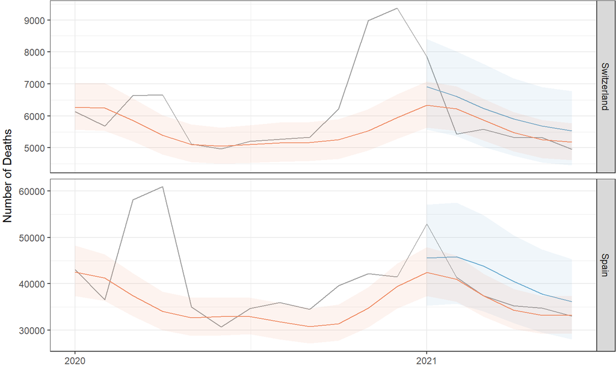

### Table 2021

| Country | Month | Observed | Including 1918 Predicted | Including 1918 Difference | Excluding 1918 Predicted (pandemic) | Excluding 1918 Difference |
| --- | --- | --- | --- | --- | --- | --- |
| Switzerland | 1 | 7848 | 6329 | 1519 | 6916 | 932 |
| Switzerland | 2 | 5429 | 6217 | -788 | 6617 | -1188 |
| Switzerland | 3 | 5579 | 5868 | -289 | 6238 | -659 |
| Switzerland | 4 | 5327 | 5487 | -160 | 5904 | -577 |
| Switzerland | 5 | 5321 | 5251 | 70 | 5677 | -356 |
| Switzerland | 6 | 4950 | 5178 | -228 | 5532 | -582 |
| Spain | 1 | 52963 | 42436 | 10527 | 45539 | 7424 |
| Spain | 2 | 41384 | 41019 | 365 | 45812 | -4428 |
| Spain | 3 | 37450 | 37426 | 24 | 43829 | -6379 |
| Spain | 4 | 35236 | 34354 | 882 | 40553 | -5317 |
| Spain | 5 | 34788 | 33154 | 1634 | 37786 | -2998 |
| Spain | 6 | 33005 | 33275 | -270 | 36157 | -3152 |

## Pandemic compared to last year

**2021 not included yet since not a full year!**

### Absolute

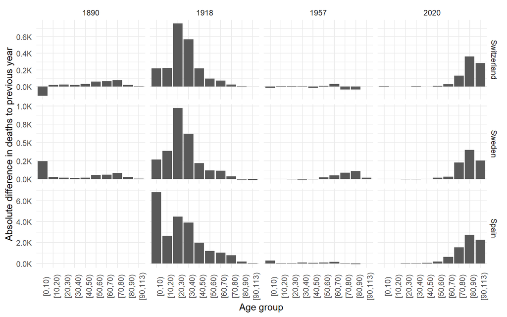

### Relative

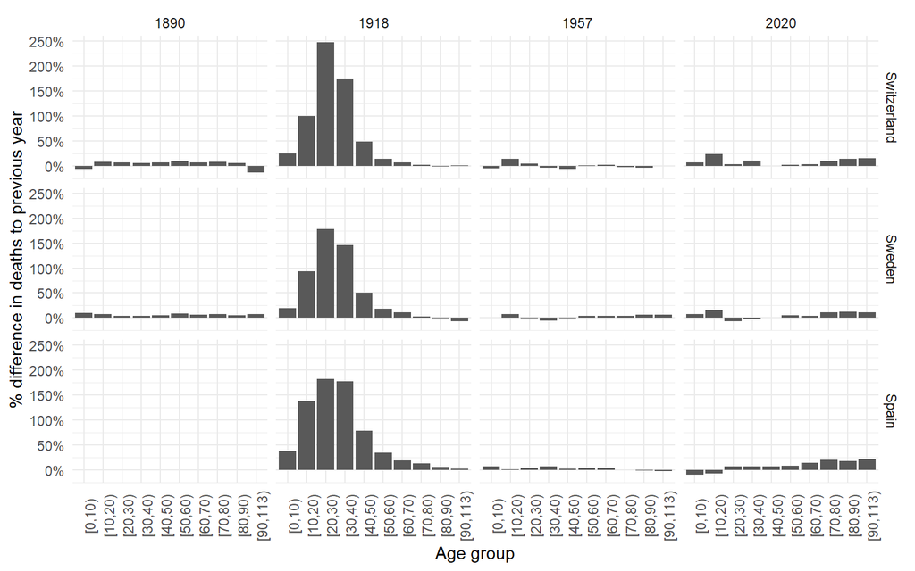

## Comparing to BfS estimates

Data from BfS prepared in `03`. No CI included in comparisons since different age groups are used.

| Year | Excess_BfS | Excess_modelled | Difference |
| --- | --- | --- | --- |
| 2010 | 696 | 314 | -382 |
| 2011 | -672 | -1651 | -979 |
| 2012 | 1436 | 398 | -1038 |
| 2013 | 964 | 381 | -583 |
| 2014 | -1528 | -1246 | 282 |
| 2015 | 2463 | 2397 | -66 |
| 2016 | -1994 | -2499 | -505 |
| 2017 | 166 | 460 | 294 |
| 2018 | -76 | 143 | 219 |
| 2019 | 539 | 202 | -337 |
| 2020 | 7950 | 9478 | 1528 |
| 2021 | -265 | 125 | 390 |

# Model diagnostics

## Rhat

Check that all values <1.1

```r
summary(results_month[results_month$Model != "Global Serfling", ]$Rhat)
```

```
   Min. 1st Qu.  Median    Mean 3rd Qu.    Max.
      1       1       1       1       1       1
```

## ESS

Check that all effective sample sizes are large

```r
summary(results_month[results_month$Model != "Global Serfling", ]$n_eff)
```

```
   Min. 1st Qu.  Median    Mean 3rd Qu.    Max.
   2536    3354    3539    3528    3722    4312
```

## Model agreement

Example of last year

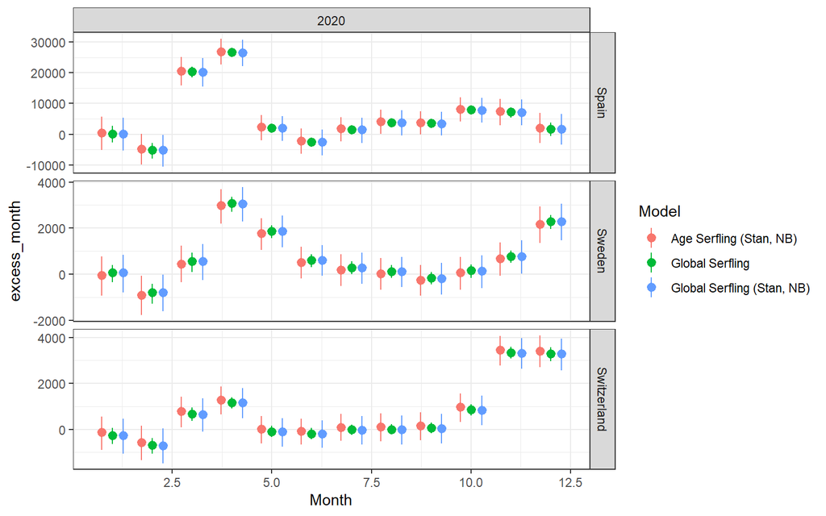

And 1918

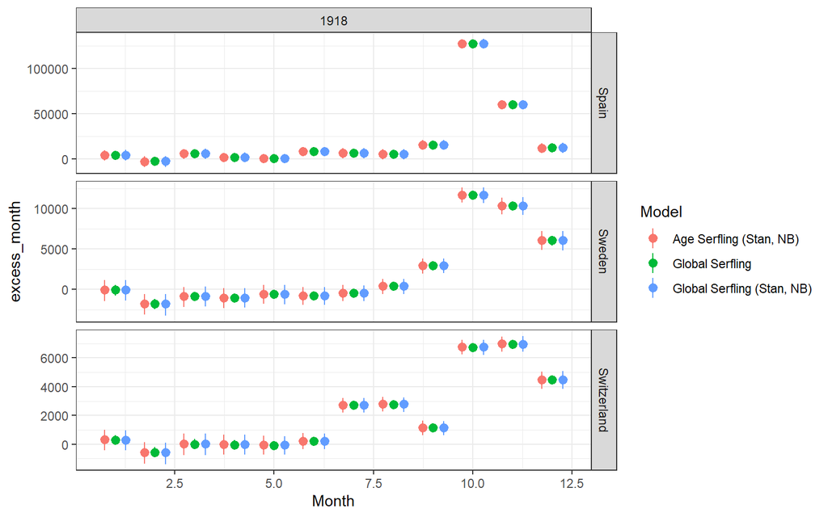

## Check age

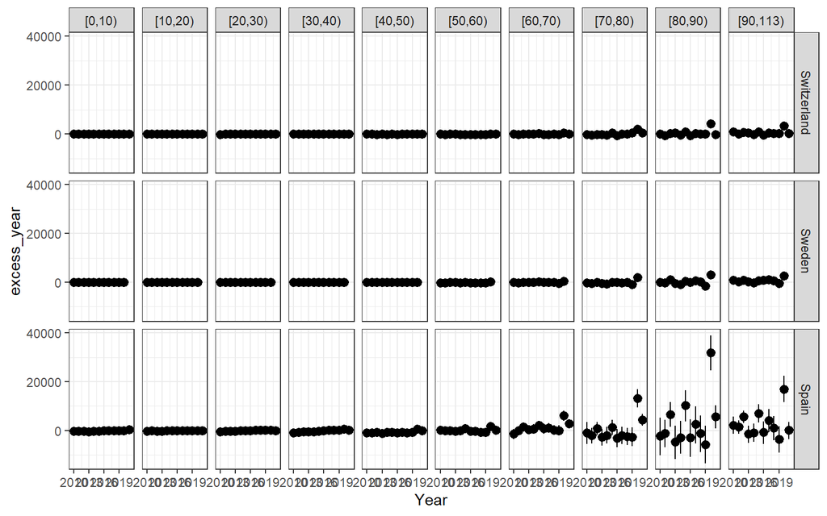

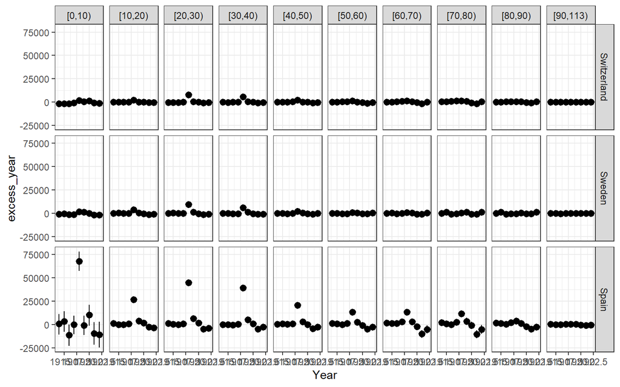

To cite R in publication use:

R Core Team (2021). *R: A Language and Environment for Statistical Computing*. R Foundation for Statistical Computing, Vienna, Austria. https://www.R-project.org/.